# Two-Way ANOVA project

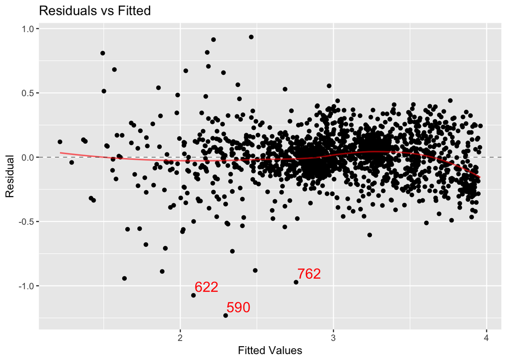

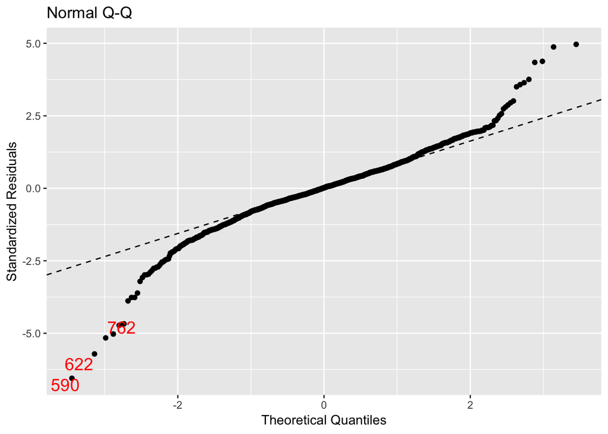

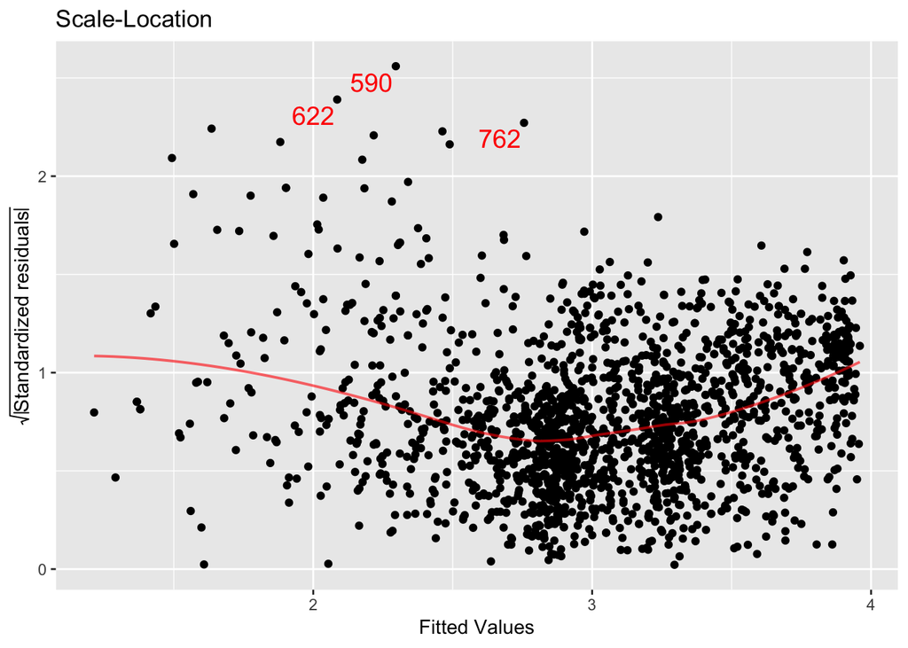

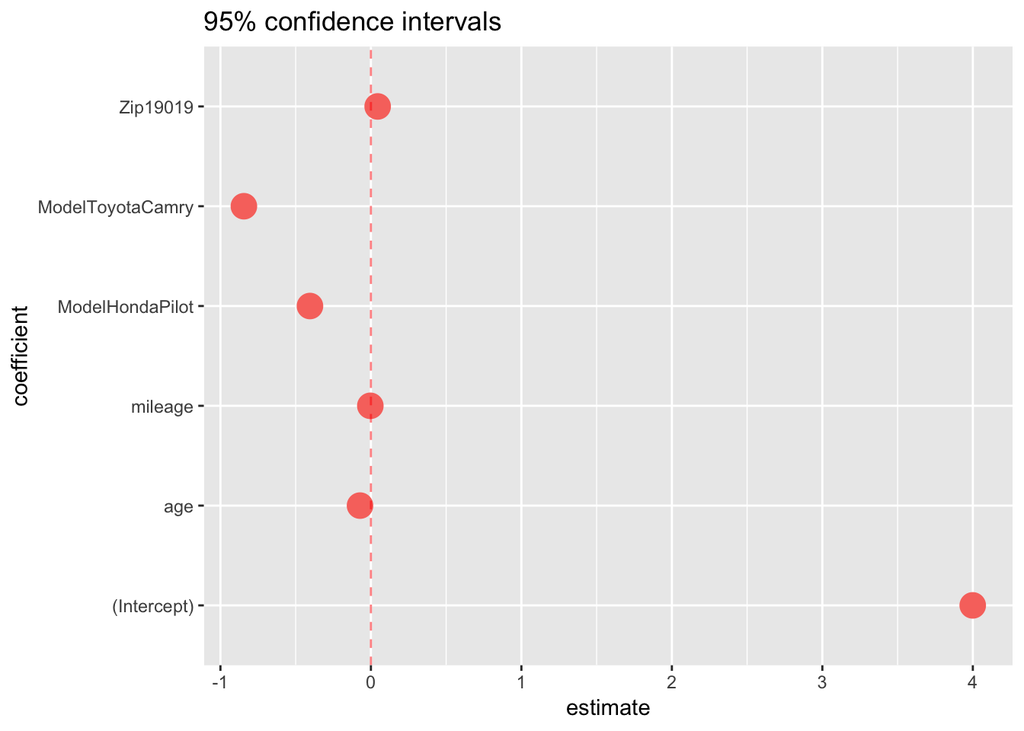

```r
CarMod3 <- lm(log(price) ~ age + mileage + Model + Zip, data = used_cars)
mplot(CarMod3)
```

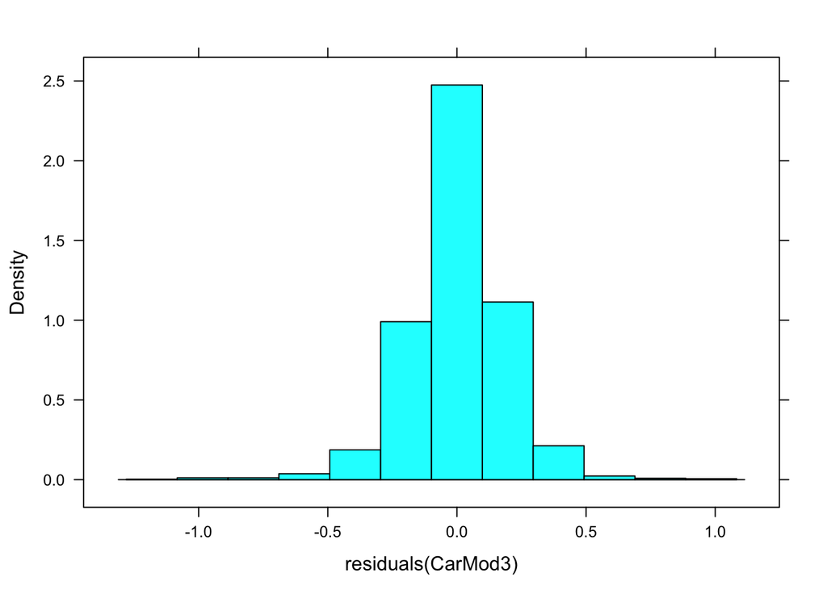

```r
histogram(residuals(CarMod3))
```

# Conclusions

Based on the ANOVA table, the p-value of age, mileage and model is less than 2.2e-16 which is much lower than the significance level of 0.05 compared to the p-value of zip code which is 6.727e-07. This result shows that all variables are significant to this model and we can reject the null hypothesis. Therefore, age, mileage, model and zip code have effects on price of these three models and two different zip codes. Moreover, after accounting for age and mileage, the model and zip code of the car will result in differences of prices.

```r
summary(CarMod3)
```

```
##
## Call:
## lm(formula = log(price) ~ age + mileage + Model + Zip, data = used_cars)
##
## Residuals:
##      Min       1Q   Median       3Q      Max
## -1.23125 -0.09458  0.00296  0.10806  0.93478
##
## Coefficients:
##                    Estimate Std. Error t value Pr(>|t|)
## (Intercept)       3.9993494  0.0113833 351.334  < 2e-16 ***
## age              -0.0723522  0.0018815 -38.454  < 2e-16 ***
## mileage          -0.0038942  0.0001646 -23.666  < 2e-16 ***
## ModelHondaPilot  -0.4051048  0.0111207 -36.428  < 2e-16 ***
## ModelToyotaCamry -0.8440889  0.0110958 -76.073  < 2e-16 ***
## Zip19019          0.0448876  0.0090005   4.987 6.73e-07 ***
## ---
## Signif. codes:  0 '***' 0.001 '**' 0.01 '*' 0.05 '.' 0.1 ' ' 1
##
## Residual standard error: 0.1887 on 1763 degrees of freedom
## Multiple R-squared:  0.8798, Adjusted R-squared:  0.8794
## F-statistic:  2580 on 5 and 1763 DF,  p-value: < 2.2e-16
```

```r
anova(CarMod3)
```

```
## Analysis of Variance Table
##
## Response: log(price)
##             Df  Sum Sq Mean Sq  F value    Pr(>F)
## age          1 238.362 238.362 6691.155 < 2.2e-16 ***
## mileage      1  13.560  13.560  380.650 < 2.2e-16 ***
## Model        2 206.697 103.349 2901.141 < 2.2e-16 ***
## Zip          1   0.886   0.886   24.873 6.727e-07 ***
## Residuals 1763  62.804   0.036
## ---
## Signif. codes:  0 '***' 0.001 '**' 0.01 '*' 0.05 '.' 0.1 ' ' 1
```